# Introduction to Incidentally

Zachary Neal, Michigan State University, zpneal@msu.edu

# Table of Contents

[figure not shown]

1. Introduction
   1. Welcome
   2. What are incidence matrices?
   3. Loading the package
   4. Package overview
2. Fill and marginal constraints
   1. Fill/Density
   2. Marginal sums
   3. Marginal distributions
3. Generative models
   1. Teams model
   2. Clubs model
   3. Organizations model
4. Utilities
   1. Randomization
   2. State space
   3. Block models

# Introduction

## Welcome

Thank you for your interest in the incidentally package! The incidentally package is designed to generate random incidence matrices and bipartite graphs under different constraints or using different generative models.

The `incidentally` package can be cited as:

**Neal, Z. P. (2022). incidentally: An R package to generate incidence matrices and bipartite graphs. *OSF Preprints*. https://doi.org/10.31219/osf.io/ectms**

For additional resources on the incidentally package, please see https://www.zacharyneal.com/incidentally. If you have questions about the incidentally package or would like an incidentally hex sticker, please contact the maintainer Zachary Neal by email (zpneal@msu.edu). Please report bugs in the incidentally package at https://github.com/zpneal/incidentally/issues.

## What are incidence matrices?

An *incidence* matrix is a binary $r \times c$ matrix **I** that records associations between $r$ objects represented by rows and $c$ objects represented by columns. In this matrix, $I_{ij} = 1$ if the i<sup>th</sup> row object is associated with the j<sup>th</sup> column object, and otherwise $I_{ij} = 0$. An incidence matrix can be used to represent a *bipartite*, *two-mode*, or *affiliation* network/graph, in which the rows represent one type of node, and the columns represent another type of node (e.g., people who author papers, species living in habitats) (Latapy, Magnien, and Del Vecchio 2008). An incidence matrix can also represent a *hypergraph*, in which each column represents a hyperedge and identifies the nodes that it connects.

For example:
$$I = \begin{bmatrix}
1 & 0 & 1 & 0 & 1\\
0 & 1 & 1 & 1 & 1\\
0 & 1 & 0 & 1 & 0
\end{bmatrix}$$
is a $3 \times 5$ incidence matrix that represents the associations of the three row objects with the five column objects. If the rows represent people and the columns represent papers they wrote, then $I_{1,1} = 1$ indicates that person 1 wrote paper 1, while $I_{1,2} = 0$ indicates that person 1 did *not* write paper 2. One key property of an incidence matrix is its marginals, or when the matrix represents a bipartite graph, its degree sequences. In this example, the row marginals are $R = \{3,4,2\}$, and the column marginals are $C = \{1,2,2,2,2\}$. This incidence matrix can also be represented as a bipartite graph, where the row nodes are labeled with uppercase letters, and the column nodes are labeled with lowercase letters:

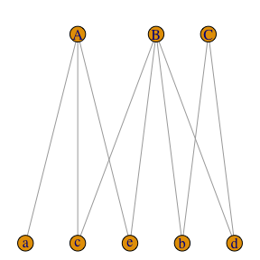

## Loading the package

The incidentally package can be loaded in the usual way:

```r
set.seed(5)
library(incidentally)
```

Upon successful loading, a startup message will display that shows the version number, citation, ways to get help, and ways to contact me. Here, we also `set.seed(5)` to ensure that the examples below are reproducible.

## Package overview

The incidentally package offers multiple incidence matrix-generating functions that differ in how the resulting incidence matrix is constrained. These functions are described in detail below, but briefly:

- `incidence.from.probability()`, `incidence.from.vector()`, and `incidence.from.distribution()` generate incidence matrices and bipartite graphs with given constraints on its fill/density and marginals/degrees.
- `incidence.from.adjacency()` uses one of several generative models to create an indicence matrix or bipartite graph from a unipartite graph.
- `curveball()` randomizes an incidence matrix or bipartite graph while preserving in marginal/degree sequence, and `add.blocks()` adds a block structure or planted partition to an existing incidence matrix or bipartite graph.
- `incidence.from.congress()` constructs an incidence matrix or bipartite graph representing US Congress legislators’ sponsorship of bills. For a detailed description of this function, and how to use it together with functions in the `backbone` package to generate political networks, see this companion vignette.

back to Table of Contents

# Fill and marginal constraints

## Fill/Density

The `incidence.from.probability()` function generates an incidence matrix or bipartite graph with a given probabaility $p$ that $I_{ij} = 1$, and thus an overall fill rate or *density* of approximately $p$. We can use it to generate a $10 \times 10$ incidence matrix in which $Pr(I_{ij} = 1) \approx .2$:

```r
I <- incidence.from.probability(10, 10, .2)
I
```

```
#>       [,1] [,2] [,3] [,4] [,5] [,6] [,7] [,8] [,9] [,10]
#>  [1,]    0    0    1    0    0    0    0    1    0     0
#>  [2,]    0    0    0    0    0    1    0    1    0     0
#>  [3,]    0    0    0    0    0    0    1    1    0     0
#>  [4,]    0    0    0    0    0    0    0    0    1     1
#>  [5,]    1    1    0    1    1    0    0    0    0     0
#>  [6,]    0    0    0    1    0    0    1    0    0     0
#>  [7,]    0    0    0    0    0    0    0    0    1     0
#>  [8,]    0    0    0    0    0    0    0    0    0     1
#>  [9,]    0    0    0    0    0    0    0    1    0     0
#> [10,]    0    0    0    0    0    0    1    0    0     0
```

```r
mean(I)  #Fill rate/density
```

```
#> [1] 0.18
```

By default, `incidence.from.probability()` only generates incidence matrices in which no rows or columns are completely empty or full. We can relax this constraint, allowing some rows/columns to contain all 0s or all 1s by specifying `constrain = FALSE`:

```r
I <- incidence.from.probability(10, 10, .2, constrain = FALSE)
I
```

```
#>       [,1] [,2] [,3] [,4] [,5] [,6] [,7] [,8] [,9] [,10]
#>  [1,]    0    0    0    1    0    0    0    0    0     0
#>  [2,]    0    0    0    1    0    0    1    0    0     0
#>  [3,]    0    0    0    0    0    0    0    1    0     1
#>  [4,]    0    0    0    0    1    0    0    1    0     0
#>  [5,]    0    0    1    0    0    0    0    0    0     1
#>  [6,]    0    0    0    0    0    0    1    0    1     0
#>  [7,]    0    0    0    0    1    0    1    1    0     0
#>  [8,]    0    0    0    0    1    0    0    0    0     0
#>  [9,]    0    0    0    0    1    0    0    0    0     0
#> [10,]    1    0    0    0    1    1    1    0    0     0
```

```r
mean(I)  #Fill rate/Density
```

```
#> [1] 0.2
```

back to Table of Contents

## Marginal sums

```r
I <- incidence.from.vector(c(4,3,2), c(1,2,2,2,2))
I
```

```
#>      [,1] [,2] [,3] [,4] [,5]
#> [1,]    1    1    1    0    1
#> [2,]    0    0    1    1    1
#> [3,]    0    1    0    1    0
```

```r
rowSums(I)  #Row marginals
```

```
#> [1] 4 3 2
```

```r
colSums(I)  #Column marginals
```

```
#> [1] 1 2 2 2 2
```

back to Table of Contents

## Marginal distributions

The `incidence.from.distributions()` function generates an incidence matrix (or bipartite graph) in which the row and column marginals (or row and column node degrees) follow Beta distributions with given shape parameters. Beta distributions are used because they can flexibly capture many different distributional shapes:

A $100 \times 100$ incidence matrix with *approximately* **uniformly distributed** row and column marginals:

```r
I <- incidence.from.distribution(R = 100, C = 100, P = 0.2,
  rowdist = c(1,1), coldist = c(1,1))
```

```
#>
#> === Suggested manuscript text and citations ===
#> We used the incidentally package for R (v1.0.3; Neal, 2022) to generate a random incidence matrix with 100 rows whose sums are approximately distributed as B(1,1), and 100 columns whose sums are approximately distributed as B(1,1).
#>
#> Neal, Z. P. (2022). incidentally: An R package to generate incidence matrices and bipartite graphs. OSF Preprints. https://doi.org/10.31219/osf.io/ectms
```

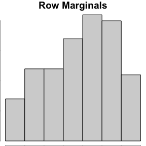

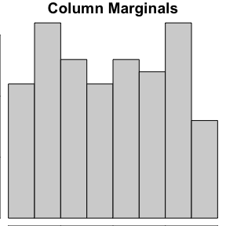

```r
hist(rowSums(I), main = "Row Marginals")
hist(colSums(I), main = "Column Marginals")
```

A $100 \times 100$ incidence matrix with *approximately* **right-tail distributed** row and column marginals:

```r
I <- incidence.from.distribution(R = 100, C = 100, P = 0.2,
  rowdist = c(1,10), coldist = c(1,10))
```

```
#>
#> === Suggested manuscript text and citations ===
#> We used the incidentally package for R (v1.0.3; Neal, 2022) to generate a random incidence matrix with 100 rows whose sums are approximately distributed as B(1,10), and 100 columns whose sums are approximately distributed as B(1,10).
#>
#> Neal, Z. P. (2022). incidentally: An R package to generate incidence matrices and bipartite graphs. OSF Preprints. https://doi.org/10.31219/osf.io/ectms
```

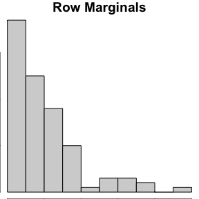

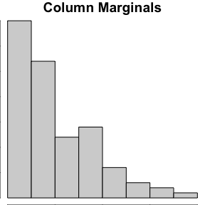

```r
hist(rowSums(I), main = "Row Marginals")
hist(colSums(I), main = "Column Marginals")
```

A $100 \times 100$ incidence matrix with *approximately* **left-tail distributed** row and column marginals:

```r
I <- incidence.from.distribution(R = 100, C = 100, P = 0.2,
  rowdist = c(10,1), coldist = c(10,1))
```

```
#>
#> === Suggested manuscript text and citations ===
#> We used the incidentally package for R (v1.0.3; Neal, 2022) to generate a random incidence matrix with 100 rows whose sums are approximately distributed as B(10,1), and 100 columns whose sums are approximately distributed as B(10,1).
#>
#> Neal, Z. P. (2022). incidentally: An R package to generate incidence matrices and bipartite graphs. OSF Preprints. https://doi.org/10.31219/osf.io/ectms
```

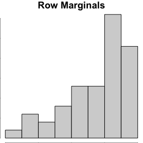

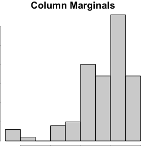

```r
hist(rowSums(I), main = "Row Marginals")
hist(colSums(I), main = "Column Marginals")
```

A $100 \times 100$ incidence matrix with *approximately* **normally distributed** row and column marginals:

```r
I <- incidence.from.distribution(R = 100, C = 100, P = 0.2,
  rowdist = c(10,10), coldist = c(10,10))
```

```
#>
#> === Suggested manuscript text and citations ===
#> We used the incidentally package for R (v1.0.3; Neal, 2022) to generate a random incidence matrix with 100 rows whose sums are approximately distributed as B(10,10), and 100 columns whose sums are approximately distributed as B(10,10).
#>
#> Neal, Z. P. (2022). incidentally: An R package to generate incidence matrices and bipartite graphs. OSF Preprints. https://doi.org/10.31219/osf.io/ectms
```

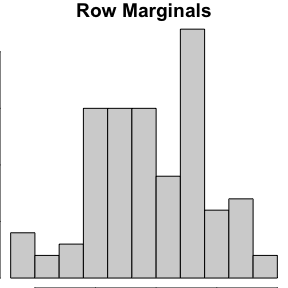

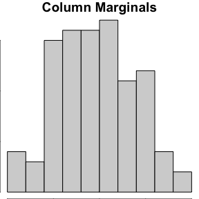

```r
hist(rowSums(I), main = "Row Marginals")
hist(colSums(I), main = "Column Marginals")
```

A $100 \times 100$ incidence matrix with *approximately* **constant** row and column marginals:

```r
I <- incidence.from.distribution(R = 100, C = 100, P = 0.2,
  rowdist = c(10000,10000), coldist = c(10000,10000))
```

```
#>
#> === Suggested manuscript text and citations ===
#> We used the incidentally package for R (v1.0.3; Neal, 2022) to generate a random incidence matrix with 100 rows whose sums are approximately distributed as B(10000,10000), and 100 columns whose sums are approximately distributed as B(10000,10000).
#>
#> Neal, Z. P. (2022). incidentally: An R package to generate incidence matrices and bipartite graphs. OSF Preprints. https://doi.org/10.31219/osf.io/ectms
```

```r
rowSums(I)
```

```
#>   [1] 20 20 20 20 20 20 20 20 20 20 20 20 20 20 20 20 20 20 20 20 20 20 20 20 20
#>  [26] 20 20 20 20 20 20 20 20 20 20 20 20 20 20 20 20 20 20 20 20 20 20 20 20 20
#>  [51] 20 20 20 20 20 20 20 20 20 20 20 20 20 20 20 20 20 20 20 20 20 20 20 20 20
#>  [76] 20 20 20 20 20 20 20 20 20 20 20 20 20 20 20 20 20 20 20 20 20 20 20 20 20
```

```r
colSums(I)
```

```
#>   [1] 20 20 20 20 20 20 20 20 20 20 20 20 20 20 20 20 20 20 20 20 20 20 20 20 20
#>  [26] 20 20 20 20 20 20 20 20 20 20 20 20 20 20 20 20 20 20 20 20 20 20 20 20 20
#>  [51] 20 20 20 20 20 20 20 20 20 20 20 20 20 20 20 20 20 20 20 20 20 20 20 20 20
#>  [76] 20 20 20 20 20 20 20 20 20 20 20 20 20 20 20 20 20 20 20 20 20 20 20 20 20
```

Different types of Beta distributions can be combined. For example, we can generate a $100 \times 100$ incidence matrix in which the row marginals are *approximately* **right-tailed**, but the column marginals are *approximately* **left-tailed**:

```r
I <- incidence.from.distribution(R = 100, C = 100, P = 0.2,
  rowdist = c(1,10), coldist = c(10,1))
```

```
#>
#> === Suggested manuscript text and citations ===
#> We used the incidentally package for R (v1.0.3; Neal, 2022) to generate a random incidence matrix with 100 rows whose sums are approximately distributed as B(1,10), and 100 columns whose sums are approximately distributed as B(10,1).
#>
#> Neal, Z. P. (2022). incidentally: An R package to generate incidence matrices and bipartite graphs. OSF Preprints. https://doi.org/10.31219/osf.io/ectms
```

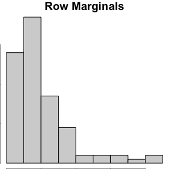

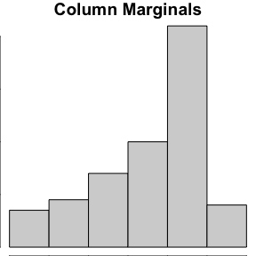

```r
hist(rowSums(I), main = "Row Marginals")
hist(colSums(I), main = "Column Marginals")
```

back to Table of Contents

# Generative models

Focus theory suggests that social networks form, in part, because individuals share *foci* such as activities that create opportunities for interaction (Feld 1981). Individuals’ memberships in foci can be represented by an incidence matrix or bipartite graph. The social network that may emerge from these foci memberships can be obtained via bipartite projection, which yields an adjacency matrix or unipartite graph in which people are connected by shared foci (Breiger 1974; Neal 2014).

## Teams model

The *teams* model mirrors a team formation process (Guimera et al. 2005) that depends on the structure of a given network in which cliques represent prior teams. Each row in the generated incidence matrix represents an agent in a given social network, while each column in the incidence matrix records the members of a team. Teams are formed from the incumbants of a randomly selected prior team (with probability $p$) and newcomers (with probability $1-p$).

Given an initial social network among 15 people, we can simulate their formation of one (`k = 1`) new team, where there is a `p = 0.75` probability that a prior team member joins the the new team:

```r
G <- erdos.renyi.game(15, .5)  #A random social network of 15 people, as igraph
I <- incidence.from.adjacency(G, k = 1, p = .75, model = "team")  #Teams model
```

```
#>
#> === Suggested manuscript text and citations ===
#> We used the incidentally package for R (v1.0.3; Neal, 2022a) to generate a random bipartite graph from a unipartite graph. The bipartite graph represents the memberships of the 15 nodes from the unipartite network in 1 newly-formed teams (Neal, 2022b).
#>
#> Neal, Z. P. (2022a). incidentally: An R package to generate incidence matrices and bipartite graphs. OSF Preprints. https://doi.org/10.31219/osf.io/ectms
#> Neal, Z. P. (2022b). The Duality of Networks and Foci: Generative Models of Two-Mode Networks from One-Mode Networks. arXiv:2204.13670 [cs.SI]. https://doi.org/10.48550/arXiv.2204.13670
```

```r
class(I)  #Incidence matrix returned as igraph object
```

```
#> [1] "igraph"
```

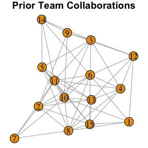

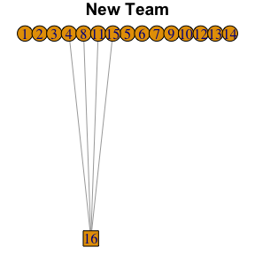

```r
V(I)$shape <- ifelse(V(I)$type, "square", "circle")  #Add shapes
plot(G, main="Prior Team Collaborations")
plot(I, layout = layout_as_bipartite(I), main="New Team")
```

Notice that because the social network `G` is supplied as a `igraph` object, the generated object `I` is returned as an `igraph` bipartite network, which facilitates subsequent plotting and analysis. In this example, a new team (node 16) is formed by four agents (nodes 4, 8, 11, and 15). The function simulates the formation of the team invisibly, so we cannot see exactly why this particular team formed. This team may have emerged from the prior 4-member team of 4, 8, 13, and 15 (they are a clique in the social network), where three positions on the new team are filled by incumbents (4, 8, and 15), while the final position is filled by a newcomer (11).

back to Table of Contents

## Clubs model

The *clubs* model mirrors a social club formation process (Backstrom et al. 2006) in which current club members try to recruit their friends. To ensure a minimum level of group cohesion, potential recruits join a newly-forming club only if doing so would yield a club in which the members’ social ties have a density of at least $p$. Each row in the generated incidence matrix represents an agent in a given social network, while each column in the incidence matrix records the members of a club.

Given an initial social network among 15 people, we can simulate their formation of one (`k = 1`) new club, where the club has a minimum density of `p = 0.75`:

```r
G <- erdos.renyi.game(15, .33)  #A random social network of 15 people, as igraph
I <- incidence.from.adjacency(G, k = 1, p = .75, model = "club")  #Groups model
```

```
#>
#> === Suggested manuscript text and citations ===
#> We used the incidentally package for R (v1.0.3; Neal, 2022a) to generate a random bipartite graph from a unipartite graph. The bipartite graph represents the memberships of the 15 nodes from the unipartite network in 1 newly-formed club (Neal, 2022b).
#>
#> Neal, Z. P. (2022a). incidentally: An R package to generate incidence matrices and bipartite graphs. OSF Preprints. https://doi.org/10.31219/osf.io/ectms
#> Neal, Z. P. (2022b). The Duality of Networks and Foci: Generative Models of Two-Mode Networks from One-Mode Networks. arXiv:2204.13670 [cs.SI]. https://doi.org/10.48550/arXiv.2204.13670
```

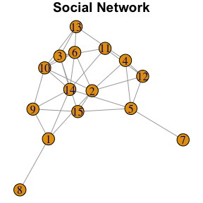

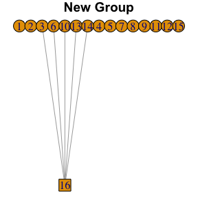

```r
V(I)$shape <- ifelse(V(I)$type, "square", "circle")  #Add shapes
plot(G, main="Social Network")
plot(I, layout = layout_as_bipartite(I), main="New Group")
```

In this example, a new club (node 16) is joined by five agents (nodes 3, 6, 10, 13, and 14). The social network among these group members is very cohesive (density = .9). The members of this group may have attempted to recruit other friends, but these others did not join because doing so would have reduced the group’s cohesion. For example, agent 10 may have tried to recruit agent 9. However, if agent 9 had joined the club, the new club would have a density of 0.73, which is lower than the minimum threshold. Therefore, agent 9 did not join the club.

back to Table of Contents

## Organizations model

The *Organizations* model mirrors an organizational recruitment process (McPherson 1983). The given social network is embedded in a $d$ dimensional social space in which the dimensions are assumed to represent meaningful social distinctions, such that socially similar people are positioned nearby. Organizations recruit members from this space, recruiting people inside their niche with probability $p$, and outside their niche with probability $1-p$. Each row in the generated incidence matrix represents an agent in a given social network, while each column in the incidence matrix records the members of an organization.

Given a social network among 15 people, we can simulate their recruitment by one (`k = 1`) new organization, where there is a `p = 0.95` probability that an individual inside an organization’s niche becomes a member:

```r
G <- erdos.renyi.game(15, .5)  #A random social network of 15 people, as igraph
I <- incidence.from.adjacency(G, k = 1, p = .95, model = "org")  #Groups model
```

```
#>
#> === Suggested manuscript text and citations ===
#> We used the incidentally package for R (v1.0.3; Neal, 2022a) to generate a random bipartite graph from a unipartite graph. The bipartite graph represents the memberships of the 15 nodes from the unipartite network in 1 newly-formed organizations (Neal, 2022b).
#>
#> Neal, Z. P. (2022a). incidentally: An R package to generate incidence matrices and bipartite graphs. OSF Preprints. https://doi.org/10.31219/osf.io/ectms
#> Neal, Z. P. (2022b). The Duality of Networks and Foci: Generative Models of Two-Mode Networks from One-Mode Networks. arXiv:2204.13670 [cs.SI]. https://doi.org/10.48550/arXiv.2204.13670
```

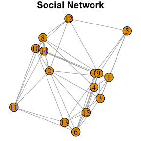

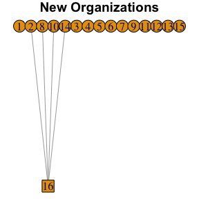

```r
V(I)$shape <- ifelse(V(I)$type, "square", "circle")  #Add shapes
plot(G, layout = layout_with_mds(G), main="Social Network")
plot(I, layout = layout_as_bipartite(I), main="New Organizations")
```

The social network is plotted using a Multidimensional Scaling layout, and therefore shows the nodes’ positions in the abstract Blau Space from which organizations recruit members. In this example, a new organization (node 16) recruits four members (nodes 2, 8, 10, and 14). This organization’s niche is located on the left side of the space, where it very successfully (because `p = 0.95`) recruits all the people in this region.

back to Table of Contents

# Utilities

## Randomization

The `curveball()` function uses the curveball algorithm (Strona et al. 2014) to randomize an incidence matrix or bipartite graph while preserving its marginal/degree sequence. The result is uniformly randomly sampled from the space of all incidence matrices (bipartite graphs) with the give marginal (degree) sequences.

For example, given a $3 \times 3$ matrix with row marginals $R = \{2,1,1\}$ and column marginals $C = \{1,1,2\}$, we can randomly sample a new matrix with the same row and column marginals:

```r
I <- matrix(c(1,0,0,0,1,0,1,0,1),3,3)
I
```

```
#>      [,1] [,2] [,3]
#> [1,]    1    0    1
#> [2,]    0    1    0
#> [3,]    0    0    1
```

```r
curveball(I)
```

```
#>      [,1] [,2] [,3]
#> [1,]    1    1    0
#> [2,]    0    0    1
#> [3,]    0    0    1
```

back to Table of Contents

## State space

The `space()` function examines the complete space of all incidence matrices with fixed marginals (i.e. all bipartite graphs with fixed degree sequences). Given a vector of row marginals and a vector of column marginals, it *attempts* to ennumerate all matrices in the space (however, a complete ennumeration is not currently guaranteed). Additionally, it computes the perturbation between each pair of matrices in this space, where perturbation is defined as the fraction of cells whose values differ.

For example, given the row marginals $R = \{2,1,1\}$ and column marginals $C = \{1,1,2\}$, we can see that there are five possible matrices, and that they vary in how much they differ from one another:

```r
space <- space(R = c(2,1,1), C = c(1,1,2))
space$matrices
```

```
#> [[1]]
#>      [,1] [,2] [,3]
#> [1,]    1    1    0
#> [2,]    0    0    1
#> [3,]    0    0    1
#>
#> [[2]]
#>      [,1] [,2] [,3]
#> [1,]    1    0    1
#> [2,]    0    0    1
#> [3,]    0    1    0
#>
#> [[3]]
#>      [,1] [,2] [,3]
#> [1,]    0    1    1
#> [2,]    1    0    0
#> [3,]    0    0    1
#>
#> [[4]]
#>      [,1] [,2] [,3]
#> [1,]    1    0    1
#> [2,]    0    1    0
#> [3,]    0    0    1
#>
#> [[5]]
#>      [,1] [,2] [,3]
#> [1,]    0    1    1
#> [2,]    0    0    1
#> [3,]    1    0    0
```

```r
space$perturbations
```

```
#>           [,1]      [,2]      [,3]      [,4]      [,5]
#> [1,] 0.0000000 0.4444444 0.4444444 0.4444444 0.4444444
#> [2,] 0.4444444 0.0000000 0.6666667 0.4444444 0.4444444
#> [3,] 0.4444444 0.6666667 0.0000000 0.4444444 0.4444444
#> [4,] 0.4444444 0.4444444 0.4444444 0.0000000 0.6666667
#> [5,] 0.4444444 0.4444444 0.4444444 0.6666667 0.0000000
```

back to Table of Contents

## Block models

The `add.blocks()` function shuffles an incidence matrix or bipartite graph to have a block structure or planted partition while preserving the row and column marginals/degrees. For example, after generating a 10 $\times$ 10 incidence matrix with a density of .2, we can plant a partition in which the within-group `density = 0.75`. In this example, the first 5 row nodes and first 5 column nodes are assigned to block 1, while the second 5 row nodes and second 5 column nodes are assigned to block 2:

```r
I <- incidence.from.probability(R = 10, C = 10, P = .2)
blocked <- add.blocks(I, density = .75,
                       rowblock = c(1,1,1,1,1,2,2,2,2,2),
                       colblock = c(1,1,1,1,1,2,2,2,2,2))
```

```r
I  #Original matrix
```

```
#>       [,1] [,2] [,3] [,4] [,5] [,6] [,7] [,8] [,9] [,10]
#>  [1,]    1    1    0    0    1    1    1    0    0     0
#>  [2,]    0    0    0    1    0    0    0    0    1     0
#>  [3,]    0    0    0    0    0    1    0    0    1     1
#>  [4,]    0    0    0    1    0    0    0    0    0     0
#>  [5,]    0    0    0    0    0    0    0    1    0     0
#>  [6,]    0    0    1    1    0    1    0    1    0     1
#>  [7,]    1    0    1    0    0    0    0    0    0     0
#>  [8,]    0    0    0    0    1    1    0    0    0     0
#>  [9,]    1    1    0    0    0    0    1    0    0     0
#> [10,]    0    0    0    1    0    0    0    0    0     0
```

```r
blocked  #Blocked matrix
```

```
#>       [,1] [,2] [,3] [,4] [,5] [,6] [,7] [,8] [,9] [,10]
#>  [1,]    1    1    0    1    1    1    0    0    0     0
#>  [2,]    1    0    0    1    0    0    0    0    0     0
#>  [3,]    0    1    0    0    1    0    0    0    1     0
#>  [4,]    0    0    0    1    0    0    0    0    0     0
#>  [5,]    1    0    0    0    0    0    0    0    0     0
#>  [6,]    0    0    1    0    0    1    1    1    0     1
#>  [7,]    0    0    1    0    0    0    0    1    0     0
#>  [8,]    0    0    0    0    0    1    0    0    0     1
#>  [9,]    0    0    0    0    0    1    1    0    1     0
#> [10,]    0    0    0    1    0    0    0    0    0     0
```

```r
all(rowSums(I)==rowSums(blocked)) #Row marginals preserved
```

```
#> [1] TRUE
```

```r
all(colSums(I)==colSums(blocked)) #Column marginals preserved
```

```
#> [1] TRUE
```

back to Table of Contents

# References

Backstrom, Lars, Dan Huttenlocher, Jon Kleinberg, and Xiangyang Lan. 2006. “Group Formation in Large Social Networks: Membership, Growth, and Evolution.” In *Proceedings of the 12th ACM SIGKDD International Conference on Knowledge Discovery and Data Mining*, 44–54. https://doi.org/10.1145/1150402.1150412.

Breiger, Ronald L. 1974. “The Duality of Persons and Groups.” *Social Forces* 53 (2): 181–90. https://doi.org/10.1093/sf/53.2.181.

Feld, Scott L. 1981. “The Focused Organization of Social Ties.” *American Journal of Sociology* 86 (5): 1015–35. https://doi.org/10.1086/227352.

Guimera, Roger, Brian Uzzi, Jarrett Spiro, and Luis A Nunes Amaral. 2005. “Team Assembly Mechanisms Determine Collaboration Network Structure and Team Performance.” *Science* 308 (5722): 697–702. https://doi.org/10.1126/science.1106340.

Latapy, Matthieu, Clémence Magnien, and Nathalie Del Vecchio. 2008. “Basic Notions for the Analysis of Large Two-Mode Networks.” *Social Networks* 30 (1): 31–48. https://doi.org/10.1016/j.socnet.2007.04.006.

McPherson, Miller. 1983. “An Ecology of Affiliation.” *American Sociological Review*, 519–32. https://doi.org/10.2307/2117719.

Neal, Zachary P. 2014. “The Backbone of Bipartite Projections: Inferring Relationships from Co-Authorship, Co-Sponsorship, Co-Attendance and Other Co-Behaviors.” *Social Networks* 39 (October): 84–97. https://doi.org/10.1016/j.socnet.2014.06.001.

———. 2023. “The Duality of Networks and Groups: Models to Generate Two-Mode Networks from One-Mode Networks.” *Network Science*. https://doi.org/10.1017/nws.2023.3.

Strona, Giovanni, Domenico Nappo, Francesco Boccacci, Simone Fattorini, and Jesus San-Miguel-Ayanz. 2014. “A Fast and Unbiased Procedure to Randomize Ecological Binary Matrices with Fixed Row and Column Totals.” *Nature Communications* 5 (1): 1–9. https://doi.org/10.1038/ncomms5114.